# PROBLEM STATEMENT

### Assignment to build a model to predict diabetes progression using Polynomial Regression, Decision Trees, and kNN. By analyzing data, creating clear visuals, and testing various models, I'll find the best model using cross-validation. The goal is to provide simple insights and recommendations for non-experts to understand and use effectively in healthcare decisions.

#### IMPORTS

```python
import pandas as pd
import numpy as np
import matplotlib.pyplot as plt
import seaborn as sns
from sklearn.datasets import load_diabetes
from sklearn.model_selection import train_test_split, cross_validate
from sklearn.preprocessing import PolynomialFeatures
from sklearn.linear_model import LinearRegression
from sklearn.tree import DecisionTreeRegressor
from sklearn.neighbors import KNeighborsRegressor
from sklearn.metrics import r2_score, mean_absolute_error,  mean_squared_error, mean_absolute_percentage_error
from sklearn.pipeline import make_pipeline
import warnings
import random
```

#### NOTEBOOK CONFIG

```python
warnings.filterwarnings("ignore") ## Ignore package/modules warnings
pd.set_option('display.float_format', lambda x: '%.4f' % x) # Display values in dataframes as float upto 4 decimal points instead of exponents
```

## LOAD AND DESCRIBE THE DATA

```python
data = load_diabetes()
data.feature_names
```

```
['age', 'sex', 'bmi', 'bp', 's1', 's2', 's3', 's4', 's5', 's6']
```

#### Converting dataset to dataframe

```python
df = pd.DataFrame(data.data, columns=data.feature_names)
df['target'] = data.target
df.head()
```

|  | age | sex | bmi | bp | s1 | s2 | s3 | s4 | s5 | s6 | target |
| --- | --- | --- | --- | --- | --- | --- | --- | --- | --- | --- | --- |
| 0 | 0.0381 | 0.0507 | 0.0617 | 0.0219 | -0.0442 | -0.0348 | -0.0434 | -0.0026 | 0.0199 | -0.0176 | 151.0000 |
| 1 | -0.0019 | -0.0446 | -0.0515 | -0.0263 | -0.0084 | -0.0192 | 0.0744 | -0.0395 | -0.0683 | -0.0922 | 75.0000 |
| 2 | 0.0853 | 0.0507 | 0.0445 | -0.0057 | -0.0456 | -0.0342 | -0.0324 | -0.0026 | 0.0029 | -0.0259 | 141.0000 |
| 3 | -0.0891 | -0.0446 | -0.0116 | -0.0367 | 0.0122 | 0.0250 | -0.0360 | 0.0343 | 0.0227 | -0.0094 | 206.0000 |
| 4 | 0.0054 | -0.0446 | -0.0364 | 0.0219 | 0.0039 | 0.0156 | 0.0081 | -0.0026 | -0.0320 | -0.0466 | 135.0000 |

#### Getting valuable insights

```python
df.describe()
```

|  | age | sex | bmi | bp | s1 | s2 | s3 | s4 | s5 | s6 | target |
| --- | --- | --- | --- | --- | --- | --- | --- | --- | --- | --- | --- |
| count | 442.0000 | 442.0000 | 442.0000 | 442.0000 | 442.0000 | 442.0000 | 442.0000 | 442.0000 | 442.0000 | 442.0000 | 442.0000 |
| mean | -0.0000 | 0.0000 | -0.0000 | -0.0000 | -0.0000 | 0.0000 | -0.0000 | -0.0000 | 0.0000 | 0.0000 | 152.1335 |
| std | 0.0476 | 0.0476 | 0.0476 | 0.0476 | 0.0476 | 0.0476 | 0.0476 | 0.0476 | 0.0476 | 0.0476 | 77.0930 |
| min | -0.1072 | -0.0446 | -0.0903 | -0.1124 | -0.1268 | -0.1156 | -0.1023 | -0.0764 | -0.1261 | -0.1378 | 25.0000 |
| 25% | -0.0373 | -0.0446 | -0.0342 | -0.0367 | -0.0342 | -0.0304 | -0.0351 | -0.0395 | -0.0332 | -0.0332 | 87.0000 |
| 50% | 0.0054 | -0.0446 | -0.0073 | -0.0057 | -0.0043 | -0.0038 | -0.0066 | -0.0026 | -0.0019 | -0.0011 | 140.5000 |
| 75% | 0.0381 | 0.0507 | 0.0312 | 0.0356 | 0.0284 | 0.0298 | 0.0293 | 0.0343 | 0.0324 | 0.0279 | 211.5000 |
| max | 0.1107 | 0.0507 | 0.1706 | 0.1320 | 0.1539 | 0.1988 | 0.1812 | 0.1852 | 0.1336 | 0.1356 | 346.0000 |

#### Plotting differnt graphs to visualize our data

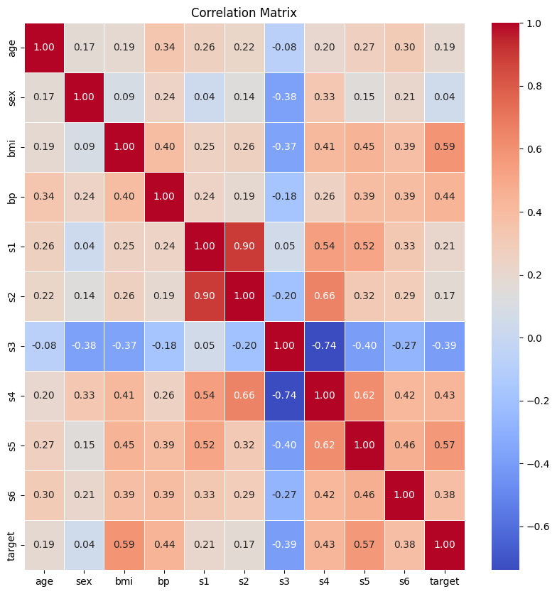

```python
# Correlation matrix
correlation_matrix = df.corr()

plt.figure(figsize=(10, 10))
sns.heatmap(correlation_matrix, annot=True, cmap='coolwarm', fmt=".2f", linewidths=.5)
plt.title('Correlation Matrix')
plt.show()
```

#### Selecting 4 columns with best correlation with the dependent variable 'target'

```python
correlation_with_target = correlation_matrix['target'].abs().sort_values(ascending=False)[:5]
correlation_with_target
```

```
target   1.0000
bmi      0.5865
s5       0.5659
bp       0.4415
s4       0.4305
Name: target, dtype: float64
```

#### Filterning dataframe with only these 4 columns and ignoring the rest due to low computing resources

```python
df = df[correlation_with_target.index.tolist()]
df.head()
```

|  | target | bmi | s5 | bp | s4 |
| --- | --- | --- | --- | --- | --- |
| 0 | 151.0000 | 0.0617 | 0.0199 | 0.0219 | -0.0026 |
| 1 | 75.0000 | -0.0515 | -0.0683 | -0.0263 | -0.0395 |
| 2 | 141.0000 | 0.0445 | 0.0029 | -0.0057 | -0.0026 |
| 3 | 206.0000 | -0.0116 | 0.0227 | -0.0367 | 0.0343 |
| 4 | 135.0000 | -0.0364 | -0.0320 | 0.0219 | -0.0026 |

#### Plotting graphs for the selected features

```
['bmi', 's5', 'bp', 's4']
```

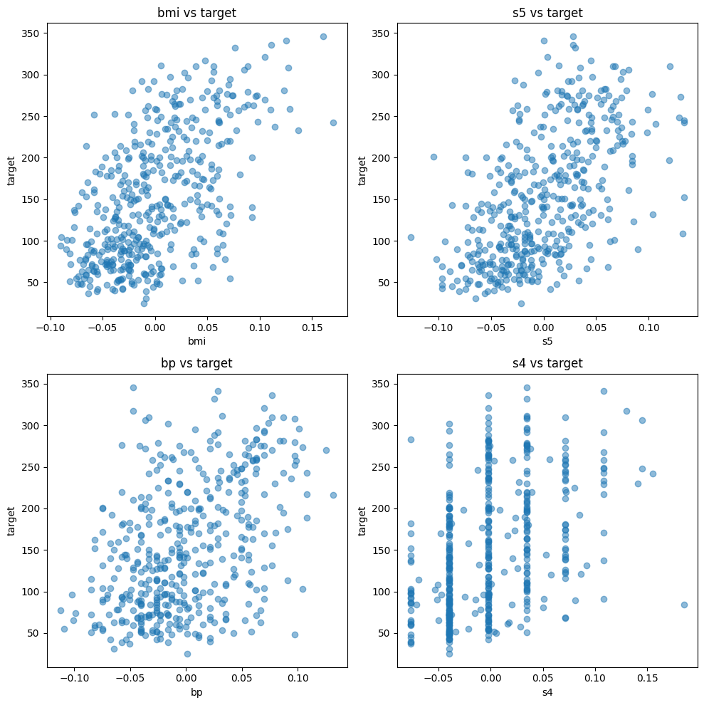

```python
features = correlation_with_target.index.tolist()[1:]
print(features)
target = 'target'

# Plot each feature against the target variable
fig, axes = plt.subplots(nrows=2, ncols=2, figsize=(10, 10))

for i, feature in enumerate(features):
    ax = axes.flatten()[i]
    ax.scatter(df[feature], df[target], alpha=0.5)
    ax.set_xlabel(feature)
    ax.set_ylabel(target)
    ax.set_title(f'{feature} vs {target}')

plt.tight_layout()
plt.show()
```

## DATA CLEANING

#### Checking for null value

```python
df.isnull().sum()
```

```
target    0
bmi       0
s5        0
bp        0
s4        0
dtype: int64
```

#### Checking for outliers

```python
# Columns to check for outliers
columns_to_check = df.columns

# Calculate Q1, Q2 (median), Q3, and IQR for each column
Q1 = df[columns_to_check].quantile(0.25)
Q2 = df[columns_to_check].median()
Q3 = df[columns_to_check].quantile(0.75)
IQR = Q3 - Q1

# Count outliers for each column
outliers = ((df[columns_to_check] < (Q1 - 1.5 * IQR)) | (df[columns_to_check] > (Q3 + 1.5 * IQR)))
outliers_count = outliers.sum()

# Create a summary table
outliers_table = pd.DataFrame({
    'Min': df[columns_to_check].min(),
    'Q1': Q1,
    'Median': Q2,
    'Q3': Q3,
    'Max': df[columns_to_check].max(),
    'IQR': IQR,
    'Outliers Count': outliers_count,
})

# Print the outliers table
outliers_table
```

|  | Min | Q1 | Median | Q3 | Max | IQR | Outliers Count |
| --- | --- | --- | --- | --- | --- | --- | --- |
| target | 25.0000 | 87.0000 | 140.5000 | 211.5000 | 346.0000 | 124.5000 | 0 |
| bmi | -0.0903 | -0.0342 | -0.0073 | 0.0312 | 0.1706 | 0.0655 | 3 |
| s5 | -0.1261 | -0.0332 | -0.0019 | 0.0324 | 0.1336 | 0.0657 | 4 |
| bp | -0.1124 | -0.0367 | -0.0057 | 0.0356 | 0.1320 | 0.0723 | 0 |
| s4 | -0.0764 | -0.0395 | -0.0026 | 0.0343 | 0.1852 | 0.0738 | 2 |

```python
total_outliers_count = outliers.any(axis=1).sum()
total_outliers_count, df.shape
```

```
(8, (442, 5))
```

```python
df = df[~outliers.any(axis=1)]
df.shape
```

```
(434, 5)
```

#### We will be splitting data into train and test with sizes 80% adn 20%

```python
X = df.drop('target', axis = 1)
Y = df['target']

X_train, X_test, Y_train, Y_test = train_test_split(X, Y, test_size=0.2, random_state=32)
X_train.shape, Y_train.shape, X_test.shape, Y_test.shape
```

```
((347, 4), (347,), (87, 4), (87,))
```

## Creating 6 differnt models for cross validation

```python
# Define polynomial models with different degrees
poly_models = {
    "Polynomial Degree 0": make_pipeline(PolynomialFeatures(degree=0), LinearRegression()),
    "Polynomial Degree 2": make_pipeline(PolynomialFeatures(degree=2), LinearRegression())
}

# Define decision tree models with different max_depth
tree_models = {
    "Decision Tree Max Depth 4": DecisionTreeRegressor(max_depth=4),
    "Decision Tree Max Depth 6": DecisionTreeRegressor(max_depth=6)
}

# Define kNN models with different number of neighbors
knn_models = {
    "kNN Neighbors 3": KNeighborsRegressor(n_neighbors=3),
    "kNN Neighbors 5": KNeighborsRegressor(n_neighbors=5)
}

# Define scoring functions
scoring = {'r2': 'r2', 'mape': 'neg_mean_absolute_percentage_error', 'mae': 'neg_mean_absolute_error'}
```

#### Performing cross-validation for Polynomial Models

```python
poly_results = []
for name, model in poly_models.items():
    poly_cv_results = cross_validate(model, X_train, Y_train, scoring=scoring, cv=5)
    r2_mean = poly_cv_results['test_r2'].mean()
    r2_std = poly_cv_results['test_r2'].std()
    mae_mean = -poly_cv_results['test_mae'].mean()
    mae_std = poly_cv_results['test_mae'].std()
    transformed_X = PolynomialFeatures(degree=model.steps[0][1].degree).fit_transform(X_train)
    mape_mean = np.mean(np.abs((Y_train - model.fit(transformed_X, Y_train).predict(transformed_X)) / Y_train)) * 100
    poly_results.append([name, r2_mean, r2_std, mae_mean, mae_std, mape_mean])
```

#### Performing cross-validation for Decision Tree Models

```python
tree_results = []
for name, model in tree_models.items():
    tree_cv_results = cross_validate(model, X_train, Y_train, scoring=scoring, cv=5)
    r2_mean = tree_cv_results['test_r2'].mean()
    r2_std = tree_cv_results['test_r2'].std()
    mae_mean = -tree_cv_results['test_mae'].mean()
    mae_std = tree_cv_results['test_mae'].std()
    mape_mean = np.mean(np.abs((Y_train - model.fit(X_train, Y_train).predict(X_train)) / Y_train)) * 100
    tree_results.append([name, r2_mean, r2_std, mae_mean, mae_std, mape_mean])
```

#### Performing cross-validation for kNN Models

```python
knn_results = []
for name, model in knn_models.items():
    knn_cv_results = cross_validate(model, X_train, Y_train, scoring=scoring, cv=5)
    r2_mean = knn_cv_results['test_r2'].mean()
    r2_std = knn_cv_results['test_r2'].std()
    mae_mean = -knn_cv_results['test_mae'].mean()
    mae_std = knn_cv_results['test_mae'].std()
    mape_mean = np.mean(np.abs((Y_train - model.fit(X_train, Y_train).predict(X_train)) / Y_train)) * 100
    knn_results.append([name, r2_mean, r2_std, mae_mean, mae_std, mape_mean])
```

#### Combine results of all three models into a single DataFrame

```python
summary_df = pd.DataFrame(poly_results + tree_results + knn_results,
                          columns=['Model', 'R2 Mean', 'R2 STD', 'MAE Mean', 'MAE STD', 'MAPE Mean'])

summary_df
```

|  | Model | R2 Mean | R2 STD | MAE Mean | MAE STD | MAPE Mean |
| --- | --- | --- | --- | --- | --- | --- |
| 0 | Polynomial Degree 0 | -0.0103 | 0.0079 | 65.8462 | 6.0322 | 62.0102 |
| 1 | Polynomial Degree 2 | 0.4231 | 0.0526 | 48.2623 | 1.4058 | 43.8048 |
| 2 | Decision Tree Max Depth 4 | 0.2821 | 0.0478 | 52.4991 | 3.6442 | 36.1538 |
| 3 | Decision Tree Max Depth 6 | 0.1786 | 0.1387 | 54.5498 | 4.9921 | 27.9729 |
| 4 | kNN Neighbors 3 | 0.2710 | 0.0367 | 52.9546 | 2.9394 | 31.8075 |
| 5 | kNN Neighbors 5 | 0.3539 | 0.0533 | 49.5232 | 0.9334 | 35.6538 |

#### Selecting best model

```python
# Identify the best model based on the highest R-squared score
best_model_idx = summary_df[['R2 Mean']].idxmax()
best_model = summary_df.iloc[best_model_idx]
best_model
```

|  | Model | R2 Mean | R2 STD | MAE Mean | MAE STD | MAPE Mean |
| --- | --- | --- | --- | --- | --- | --- |
| 1 | Polynomial Degree 2 | 0.4231 | 0.0526 | 48.2623 | 1.4058 | 43.8048 |

#### As it can be seen from above table, Polynomial Regression of Degree 2 has best R2 Score among all models, therefore we will be using that for our value predictions.

#### Training the Polynomial regression of degree 2 on train data and check performance on test data.

```python
# Train a degree 2 polynomial regression model
poly_features = PolynomialFeatures(degree=2)
X_poly = poly_features.fit_transform(X_train)  # Transform training data
model = LinearRegression().fit(X_poly, Y_train)  # Train the model

# Predict on the test data
X_test_poly = poly_features.transform(X_test)
Y_pred = model.predict(X_test_poly)

# Calculate R-Squared
r_squared = r2_score(Y_test, Y_pred)

# Calculate MAPE
mape = np.mean(np.abs((Y_test - Y_pred) / Y_test)) * 100

# Calculate MAE
mae = mean_absolute_error(Y_test, Y_pred)

print(f"Performance on Test Data:\nR2 Score: {r_squared}\nMean Absolute Error: {mape}\nMean Absolute Percentage Error: {mae}")
```

```
Performance on Test Data:
R2 Score: 0.46704791765373344
Mean Absolute Error: 40.6018764662485
Mean Absolute Percentage Error: 44.32092158629042
```

#### Adding predicted values for dataframe features in new column

```python
X_poly_all = poly_features.fit_transform(X)
model = LinearRegression().fit(X_poly_all, Y)
Y_pred_all = model.predict(X_poly_all)
df['target_predicted'] = Y_pred_all
df.head()
```

|  | target | bmi | s5 | bp | s4 | target_predicted |
| --- | --- | --- | --- | --- | --- | --- |
| 0 | 151.0000 | 0.0617 | 0.0199 | 0.0219 | -0.0026 | 201.7088 |
| 1 | 75.0000 | -0.0515 | -0.0683 | -0.0263 | -0.0395 | 77.5630 |
| 2 | 141.0000 | 0.0445 | 0.0029 | -0.0057 | -0.0026 | 168.2484 |
| 3 | 206.0000 | -0.0116 | 0.0227 | -0.0367 | 0.0343 | 149.1064 |
| 4 | 135.0000 | -0.0364 | -0.0320 | 0.0219 | -0.0026 | 110.8396 |

#### Plotting the data points with best model line/curve

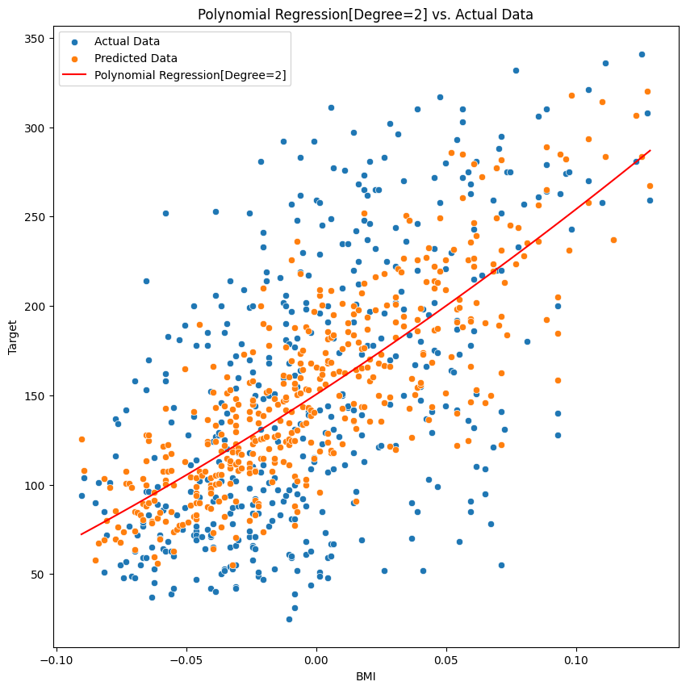

```python
plt.figure(figsize=(10, 10))

train_val_data = df[df['target_predicted'].notnull()]
test_data = df[df['target_predicted'].isnull()]

train_val_data = train_val_data.sort_values(by='bmi')
test_data = test_data.sort_values(by='bmi')

sns.scatterplot(x='bmi', y='target', data=train_val_data, label='Actual Data')
sns.scatterplot(x='bmi', y='target_predicted', data=train_val_data, label='Predicted Data')
sns.scatterplot(x='bmi', y='target', data=test_data, label='Actual Test Data')

# Fitted polynomial model
coefficients = np.polyfit(train_val_data['bmi'], train_val_data['target_predicted'], 2)
fitted_poly = np.poly1d(coefficients)
x_values = np.linspace(train_val_data['bmi'].min(), train_val_data['bmi'].max(), 100)
plt.plot(x_values, fitted_poly(x_values), label='Polynomial Regression[Degree=2]', color='red')

plt.xlabel('BMI')
plt.ylabel('Target')
plt.title('Polynomial Regression[Degree=2] vs. Actual Data')
plt.legend()

plt.show()
```